# Report Machine Learning Lab2

```
Name：李品慈                    Student ID: 0816039
```

## Data Input

```python
#!pip3 install tabulate
#!pip3 install -U scikit-learn scipy matplotlib
#!pip3 install PrettyTable
#!pip3 install graphviz
# importing panda library
import pandas as pd
import numpy as np

# ignore warnings
import warnings
warnings.filterwarnings('ignore')

# readinag given csv file
mat = pd.read_csv("student-mat.csv", sep = ';')
```

```python
mat.head()
```

|  | school | sex | age | address | famsize | Pstatus | Medu | Fedu | Mjob | Fjob | ... | famrel | freetime | goout | Dalc | Walc | health | absences | G1 | G2 | G3 |
| --- | --- | --- | --- | --- | --- | --- | --- | --- | --- | --- | --- | --- | --- | --- | --- | --- | --- | --- | --- | --- | --- |
| 0 | GP | F | 18 | U | GT3 | A | 4 | 4 | at_home | teacher | ... | 4 | 3 | 4 | 1 | 1 | 3 | 6 | 5 | 6 | 6 |
| 1 | GP | F | 17 | U | GT3 | T | 1 | 1 | at_home | other | ... | 5 | 3 | 3 | 1 | 1 | 3 | 4 | 5 | 5 | 6 |
| 2 | GP | F | 15 | U | LE3 | T | 1 | 1 | at_home | other | ... | 4 | 3 | 2 | 2 | 3 | 3 | 10 | 7 | 8 | 10 |
| 3 | GP | F | 15 | U | GT3 | T | 4 | 2 | health | services | ... | 3 | 2 | 2 | 1 | 1 | 5 | 2 | 15 | 14 | 15 |
| 4 | GP | F | 16 | U | GT3 | T | 3 | 3 | other | other | ... | 4 | 3 | 2 | 1 | 2 | 5 | 4 | 6 | 10 | 10 |

5 rows × 33 columns

## Data preprocessing

```python
# Transform categorical features into one-hot representation.
mat = pd.get_dummies(mat)
mat = pd.DataFrame(mat)

# Shuffle the data
mat = mat.sample(frac=1)

# Transform label format so you can do the required two tasks described below Data section.

#################################### Do something Here #######################################

# Show data
mat
```

|  | age | Medu | Fedu | traveltime | studytime | failures | famrel | freetime | goout | Dalc | ... | activities_no | activities_yes | nursery_no | nursery_yes | higher_no | higher_yes | internet_no | internet_yes | romantic_no | romantic_yes |
| --- | --- | --- | --- | --- | --- | --- | --- | --- | --- | --- | --- | --- | --- | --- | --- | --- | --- | --- | --- | --- | --- |
| 187 | 16 | 2 | 1 | 1 | 2 | 0 | 4 | 2 | 3 | 1 | ... | 0 | 1 | 0 | 1 | 0 | 1 | 0 | 1 | 0 | 1 |
| 292 | 18 | 2 | 1 | 1 | 2 | 1 | 5 | 4 | 3 | 1 | ... | 1 | 0 | 0 | 1 | 0 | 1 | 0 | 1 | 0 | 1 |
| 295 | 17 | 3 | 3 | 1 | 1 | 0 | 4 | 4 | 3 | 1 | ... | 1 | 0 | 0 | 1 | 0 | 1 | 0 | 1 | 1 | 0 |
| 138 | 16 | 1 | 1 | 1 | 2 | 1 | 4 | 4 | 4 | 1 | ... | 1 | 0 | 0 | 1 | 0 | 1 | 1 | 0 | 0 | 1 |
| 14 | 15 | 2 | 2 | 1 | 3 | 0 | 4 | 5 | 2 | 1 | ... | 1 | 0 | 0 | 1 | 0 | 1 | 0 | 1 | 0 | 1 |
| ... | ... | ... | ... | ... | ... | ... | ... | ... | ... | ... | ... | ... | ... | ... | ... | ... | ... | ... | ... | ... | ... |
| 382 | 17 | 2 | 3 | 2 | 2 | 0 | 4 | 4 | 3 | 1 | ... | 0 | 1 | 0 | 1 | 0 | 1 | 0 | 1 | 1 | 0 |
| 269 | 18 | 2 | 1 | 2 | 2 | 0 | 4 | 3 | 5 | 1 | ... | 1 | 0 | 0 | 1 | 1 | 0 | 0 | 1 | 0 | 1 |
| 308 | 19 | 3 | 3 | 1 | 2 | 1 | 4 | 5 | 3 | 1 | ... | 0 | 1 | 0 | 1 | 0 | 1 | 1 | 0 | 0 | 1 |
| 384 | 18 | 4 | 2 | 2 | 1 | 1 | 5 | 4 | 3 | 4 | ... | 1 | 0 | 0 | 1 | 0 | 1 | 1 | 0 | 1 | 0 |
| 171 | 16 | 1 | 0 | 2 | 2 | 0 | 4 | 3 | 2 | 1 | ... | 0 | 1 | 0 | 1 | 0 | 1 | 0 | 1 | 0 | 1 |

395 rows × 59 columns

```python
#mat.columns
```

## Set X, y(y has two kinds: binary and 5-level)

```python
# set X, y
X = mat.drop('G3', axis = 1)
y = mat['G3']

binary_y = []
five_level_y = []

# set binary y and 5-level y
for num in y:
    if(num >= 10):
        binary_y.append('pass')
    else:
        binary_y.append('fail')
    if(num >= 16 and num <=20):
        five_level_y.append('A')
    elif(num >= 14 and num <=15):
        five_level_y.append('B')
    elif(num >= 12 and num <=13):
        five_level_y.append('C')
    elif(num >= 10 and num <=11):
        five_level_y.append('D')
    else:
        five_level_y.append('F')

binary_y = pd.DataFrame(binary_y)
five_level_y = pd.DataFrame(five_level_y)
```

```python
'''
# used to calculate how much label
from itertools import chain

list_y = binary_y.values.tolist()
list_y = list(chain.from_iterable(list_y))
print('pass: ', list_y.count('pass'))
print('fail: ', list_y.count('fail'))

list_y = five_level_y.values.tolist()
list_y = list(chain.from_iterable(list_y))
print('A: ', list_y.count('A'))
print('B: ', list_y.count('B'))
print('C: ', list_y.count('C'))
print('D: ', list_y.count('D'))
print('F: ', list_y.count('F'))
'''
```

[output not shown]

## Model Construction: Decision Tree without PCA for binary classification

```python
from sklearn import tree

DecisionTreeNPCA_model=tree.DecisionTreeClassifier()
```

```python
import statistics
from sklearn.model_selection import StratifiedKFold
from sklearn.metrics import confusion_matrix
from sklearn.metrics._classification import accuracy_score
from sklearn.metrics._classification import recall_score
from sklearn.metrics._classification import precision_score
from tabulate import tabulate

folds = StratifiedKFold(n_splits=3)

binary_label = ['pass', 'fail']

accscores = []
recscores = []
prescores = []

cm_holder = []

for train_index, test_index in folds.split(X,binary_y):
    X_train, X_test, y_train, y_test = X.iloc[train_index], X.iloc[test_index], \
                                       binary_y.iloc[train_index], binary_y.iloc[test_index]
    # test model
    DecisionTreeNPCA_model.fit(X_train, y_train)
    y_predict = DecisionTreeNPCA_model.predict(X_test)
    cm_holder.append(confusion_matrix(y_test, y_predict, labels = binary_label))
    accscores.append(accuracy_score(y_test, y_predict))
    recscores.append(recall_score(y_test, y_predict, average='macro'))
    prescores.append(precision_score(y_test, y_predict, average='macro'))
```

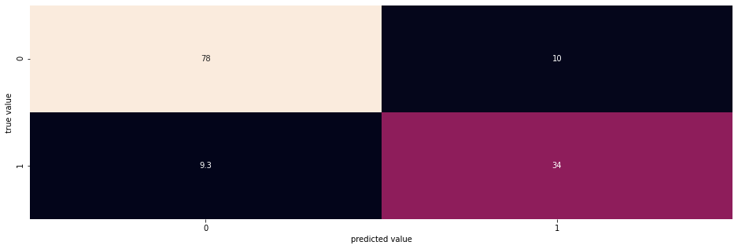

```
+------------+----------+-------------+
|   accuracy |   recall |   precision |
+============+==========+=============+
|   0.853111 | 0.835551 |    0.833705 |
+------------+----------+-------------+
```

```python
import matplotlib.pyplot as plt
import seaborn as sns

# results: confusion matrix
ma = sum(cm_holder)/3
plt.figure(figsize = (16,5))
sns.heatmap(ma, square= False, annot=True, cbar= False)
plt.xlabel("predicted value")
plt.ylabel("true value")
plt.show()

# results: accuracy
accuracy = statistics.mean(accscores)

# results: sensitivity(recall)
recall = statistics.mean(recscores)

# results: precision
precision = statistics.mean(prescores)

# draw table with accuracy, recall, precision
data = [[accuracy, recall, precision]]

headers = ["accuracy", "recall", "precision"]

print(tabulate(data, headers= headers, tablefmt= "grid"))
```

## Model Construction: Decision Tree without PCA for 5-level classification

```python
DecisionTreeNPCA_model2=tree.DecisionTreeClassifier()
```

```python
folds = StratifiedKFold(n_splits=3)

five_level_label = ["A", "B", "C", "D", "F"] # A = 0, B = 1, ...

accscores2 = []
recscores2 = []
prescores2 = []

cm_holder2 = []

for train_index, test_index in folds.split(X,five_level_y):
    X_train, X_test, y_train, y_test = X.iloc[train_index], X.iloc[test_index], \
                                       five_level_y.iloc[train_index], five_level_y.iloc[test_index]
    # test model
    DecisionTreeNPCA_model2.fit(X_train, y_train)
    y_predict = DecisionTreeNPCA_model2.predict(X_test)
    cm_holder2.append(confusion_matrix(y_test, y_predict, labels = five_level_label))
    accscores2.append(accuracy_score(y_test, y_predict))
    recscores2.append(recall_score(y_test, y_predict, average='macro'))
    prescores2.append(precision_score(y_test, y_predict, average='macro'))
```

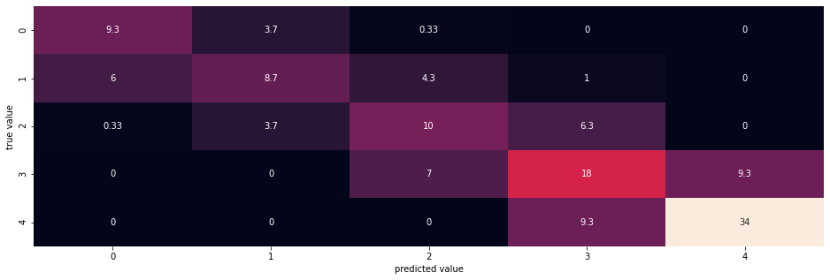

```
+------------+----------+-------------+
|   accuracy |   recall |   precision |
+============+==========+=============+
|   0.609935 | 0.588308 |     0.58679 |
+------------+----------+-------------+
```

```python
# results: confusion matrix
ma2 = sum(cm_holder2)/3
plt.figure(figsize = (16,5))
sns.heatmap(ma2,square= False, annot=True, cbar= False)
plt.xlabel("predicted value")
plt.ylabel("true value")
plt.show()

# results: accuracy
accuracy2 = statistics.mean(accscores2)

# results: sensitivity(recall)
recall2 = statistics.mean(recscores2)

# results: precision
precision2 = statistics.mean(prescores2)

# draw table with accuracy, recall, precision
data2 = [[accuracy2, recall2, precision2]]

headers = ["accuracy", "recall", "precision"]

print(tabulate(data2, headers= headers, tablefmt= "grid"))
```

## Model Construction: Random forest without PCA for binary classification

### Note: difference between K-fold cross-validation and Random Forest

- K-fold cross validation: 一種驗證方式。將給定的dataset分成k份，每次取k-1份進行training(fit)，剩餘的1份用於testing(predict)，此動作重複k次，每次使用不同的testing，最後將score平均即為該model的performance。
- Random forest: 一種classifier。從給定的dataset中選定bootstrap(同一資料可被重複取用)，再從bootstrap data中隨機選取features(或samples)，生成tree，重複上列動作生成多棵tree。Predict由多棵樹共同決定，計算每棵樹的結果，最高票數的label則為predict.

```python
from sklearn import ensemble

RandomForestNPCA10_model=ensemble.RandomForestClassifier(n_estimators = 10)
RandomForestNPCA100_model=ensemble.RandomForestClassifier(n_estimators = 100)
RandomForestNPCA1000_model=ensemble.RandomForestClassifier(n_estimators = 1000)
```

```python
folds = StratifiedKFold(n_splits=3)

accscores3 = []
recscores3 = []
prescores3 = []
cm_holder3 = []

accscores4 = []
recscores4 = []
prescores4 = []
cm_holder4 = []

accscores5 = []
recscores5 = []
prescores5 = []
cm_holder5 = []

for train_index, test_index in folds.split(X,binary_y):
    X_train, X_test, y_train, y_test = X.iloc[train_index], X.iloc[test_index], \
                                       binary_y.iloc[train_index], binary_y.iloc[test_index]
    # test model
    RandomForestNPCA10_model.fit(X_train, y_train)
    y_predict = RandomForestNPCA10_model.predict(X_test)
    cm_holder3.append(confusion_matrix(y_test, y_predict, labels = binary_label))
    accscores3.append(accuracy_score(y_test, y_predict))
    recscores3.append(recall_score(y_test, y_predict, average='macro'))
    prescores3.append(precision_score(y_test, y_predict, average='macro'))

    RandomForestNPCA100_model.fit(X_train, y_train)
    y_predict = RandomForestNPCA100_model.predict(X_test)
    cm_holder4.append(confusion_matrix(y_test, y_predict, labels = binary_label))
    accscores4.append(accuracy_score(y_test, y_predict))
    recscores4.append(recall_score(y_test, y_predict, average='macro'))
    prescores4.append(precision_score(y_test, y_predict, average='macro'))

    RandomForestNPCA1000_model.fit(X_train, y_train)
    y_predict = RandomForestNPCA1000_model.predict(X_test)
    cm_holder5.append(confusion_matrix(y_test, y_predict, labels = binary_label))
    accscores5.append(accuracy_score(y_test, y_predict))
    recscores5.append(recall_score(y_test, y_predict, average='macro'))
    prescores5.append(precision_score(y_test, y_predict, average='macro'))
```

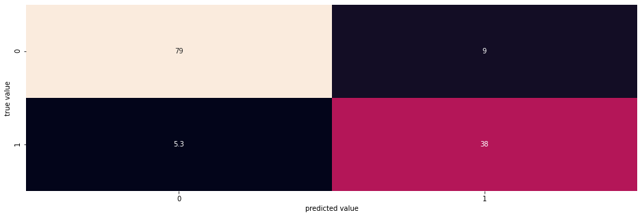

```
+------------+----------+-------------+
|   accuracy |   recall |   precision |
+============+==========+=============+
|   0.891106 | 0.887544 |    0.875899 |
+------------+----------+-------------+
```

```python
# results: confusion matrix
ma3 = sum(cm_holder3)/3
plt.figure(figsize = (16,5))
sns.heatmap(ma3,square= False, annot=True, cbar= False)
plt.xlabel("predicted value")
plt.ylabel("true value")
plt.show()

# results: accuracy
accuracy3 = statistics.mean(accscores3)

# results: sensitivity(recall)
recall3 = statistics.mean(recscores3)

# results: precision
precision3 = statistics.mean(prescores3)

# draw table with accuracy, recall, precision
data3 = [[accuracy3, recall3, precision3]]

headers = ["accuracy", "recall", "precision"]

print(tabulate(data3, headers= headers, tablefmt= "grid"))
```

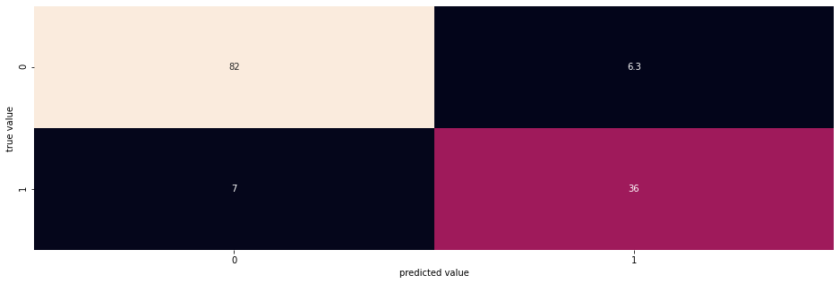

```
+------------+----------+-------------+
|   accuracy |   recall |   precision |
+============+==========+=============+
|    0.89872 | 0.883273 |    0.888617 |
+------------+----------+-------------+
```

```python
# results: confusion matrix
ma4 = sum(cm_holder4)/3
plt.figure(figsize = (16,5))
sns.heatmap(ma4,square= False, annot=True, cbar= False)
plt.xlabel("predicted value")
plt.ylabel("true value")
plt.show()

# results: accuracy
accuracy4 = statistics.mean(accscores4)

# results: sensitivity(recall)
recall4 = statistics.mean(recscores4)

# results: precision
precision4 = statistics.mean(prescores4)

# draw table with accuracy, recall, precision
data4 = [[accuracy4, recall4, precision4]]

headers = ["accuracy", "recall", "precision"]

print(tabulate(data4, headers= headers, tablefmt= "grid"))
```

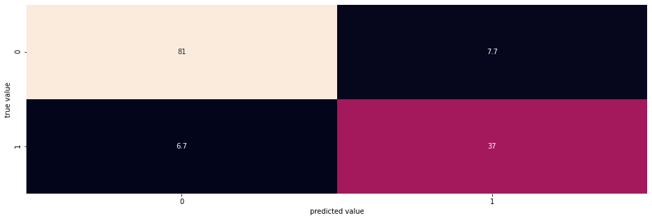

```
+------------+----------+-------------+
|   accuracy |   recall |   precision |
+============+==========+=============+
|   0.891125 | 0.879506 |    0.877384 |
+------------+----------+-------------+
```

```python
# results: confusion matrix
ma5 = sum(cm_holder5)/3
plt.figure(figsize = (16,5))
sns.heatmap(ma5,square= False, annot=True, cbar= False)
plt.xlabel("predicted value")
plt.ylabel("true value")
plt.show()

# results: accuracy
accuracy5 = statistics.mean(accscores5)

# results: sensitivity(recall)
recall5 = statistics.mean(recscores5)

# results: precision
precision5 = statistics.mean(prescores5)

# draw table with accuracy, recall, precision
data5 = [[accuracy5, recall5, precision5]]

headers = ["accuracy", "recall", "precision"]

print(tabulate(data5, headers= headers, tablefmt= "grid"))
```

## Model Construction: Random forest without PCA for 5-level classification

```python
RandomForestNPCA10_model2=ensemble.RandomForestClassifier(n_estimators = 10)
RandomForestNPCA100_model2=ensemble.RandomForestClassifier(n_estimators = 100)
RandomForestNPCA1000_model2=ensemble.RandomForestClassifier(n_estimators = 1000)
```

```python
folds = StratifiedKFold(n_splits=3)

accscores6 = []
recscores6 = []
prescores6 = []
cm_holder6 = []

accscores7 = []
recscores7 = []
prescores7 = []
cm_holder7 = []

accscores8 = []
recscores8 = []
prescores8 = []
cm_holder8 = []

for train_index, test_index in folds.split(X,five_level_y):
    X_train, X_test, y_train, y_test = X.iloc[train_index], X.iloc[test_index], \
                                       five_level_y.iloc[train_index], five_level_y.iloc[test_index]
    # test model
    RandomForestNPCA10_model2.fit(X_train, y_train)
    y_predict = RandomForestNPCA10_model2.predict(X_test)
    cm_holder6.append(confusion_matrix(y_test, y_predict, labels = five_level_label))
    accscores6.append(accuracy_score(y_test, y_predict))
    recscores6.append(recall_score(y_test, y_predict, average='macro'))
    prescores6.append(precision_score(y_test, y_predict, average='macro'))

    RandomForestNPCA100_model2.fit(X_train, y_train)
    y_predict = RandomForestNPCA100_model2.predict(X_test)
    cm_holder7.append(confusion_matrix(y_test, y_predict, labels = five_level_label))
    accscores7.append(accuracy_score(y_test, y_predict))
    recscores7.append(recall_score(y_test, y_predict, average='macro'))
    prescores7.append(precision_score(y_test, y_predict, average='macro'))

    RandomForestNPCA1000_model2.fit(X_train, y_train)
    y_predict = RandomForestNPCA1000_model2.predict(X_test)
    cm_holder8.append(confusion_matrix(y_test, y_predict, labels = five_level_label))
    accscores8.append(accuracy_score(y_test, y_predict))
    recscores8.append(recall_score(y_test, y_predict, average='macro'))
    prescores8.append(precision_score(y_test, y_predict, average='macro'))
```

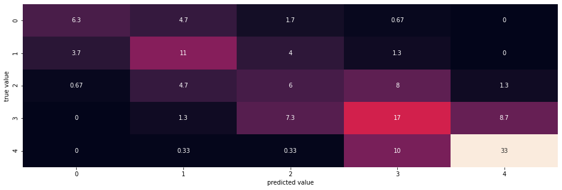

```
+------------+----------+-------------+
|   accuracy |   recall |   precision |
+============+==========+=============+
|   0.554495 | 0.513222 |    0.528905 |
+------------+----------+-------------+
```

```python
# results: confusion matrix
ma6 = sum(cm_holder6)/3
plt.figure(figsize = (16,5))
sns.heatmap(ma6,square= False, annot=True, cbar= False)
plt.xlabel("predicted value")
plt.ylabel("true value")
plt.show()

# results: accuracy
accuracy6 = statistics.mean(accscores6)

# results: sensitivity(recall)
recall6 = statistics.mean(recscores6)

# results: precision
precision6 = statistics.mean(prescores6)

# draw table with accuracy, recall, precision
data6 = [[accuracy6, recall6, precision6]]

headers = ["accuracy", "recall", "precision"]

print(tabulate(data6, headers= headers, tablefmt= "grid"))
```

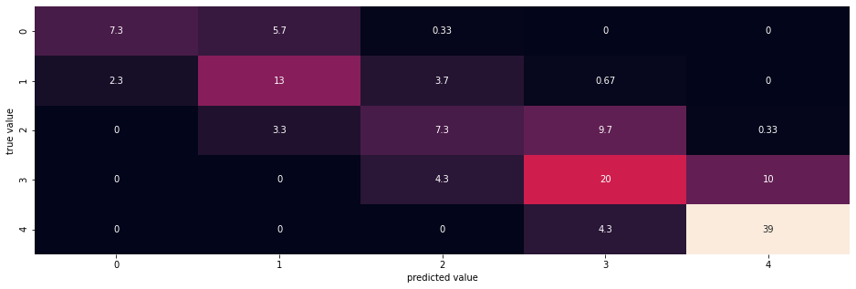

```
+------------+----------+-------------+
|   accuracy |   recall |   precision |
+============+==========+=============+
|   0.660903 | 0.611071 |    0.645896 |
+------------+----------+-------------+
```

```python
# results: confusion matrix
ma7 = sum(cm_holder7)/3
plt.figure(figsize = (16,5))
sns.heatmap(ma7,square= False, annot=True, cbar= False)
plt.xlabel("predicted value")
plt.ylabel("true value")
plt.show()

# results: accuracy
accuracy7 = statistics.mean(accscores7)

# results: sensitivity(recall)
recall7 = statistics.mean(recscores7)

# results: precision
precision7 = statistics.mean(prescores7)

# draw table with accuracy, recall, precision
data7 = [[accuracy7, recall7, precision7]]

headers = ["accuracy", "recall", "precision"]

print(tabulate(data7, headers= headers, tablefmt= "grid"))
```

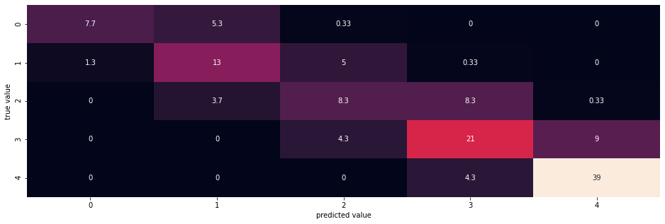

```
+------------+----------+-------------+
|   accuracy |   recall |   precision |
+============+==========+=============+
|    0.67856 | 0.631503 |    0.676177 |
+------------+----------+-------------+
```

```python
# results: confusion matrix
ma8 = sum(cm_holder8)/3
plt.figure(figsize = (16,5))
sns.heatmap(ma8,square= False, annot=True, cbar= False)
plt.xlabel("predicted value")
plt.ylabel("true value")
plt.show()

# results: accuracy
accuracy8 = statistics.mean(accscores8)

# results: sensitivity(recall)
recall8 = statistics.mean(recscores8)

# results: precision
precision8 = statistics.mean(prescores8)

# draw table with accuracy, recall, precision
data8 = [[accuracy8, recall8, precision8]]

headers = ["accuracy", "recall", "precision"]

print(tabulate(data8, headers= headers, tablefmt= "grid"))
```

## Model Construction: KNN without PCA for binary classification

```python
from sklearn.neighbors import KNeighborsClassifier

KNNNPCA5_model = KNeighborsClassifier(n_neighbors=5)
KNNNPCA10_model = KNeighborsClassifier(n_neighbors=10)
KNNNPCA15_model = KNeighborsClassifier(n_neighbors=15)
```

```python
folds = StratifiedKFold(n_splits=3)

accscores9 = []
recscores9 = []
prescores9 = []
cm_holder9 = []

accscores10 = []
recscores10 = []
prescores10 = []
cm_holder10 = []

accscores11 = []
recscores11 = []
prescores11 = []
cm_holder11 = []

for train_index, test_index in folds.split(X,binary_y):
    X_train, X_test, y_train, y_test = X.iloc[train_index], X.iloc[test_index], \
                                       binary_y.iloc[train_index], binary_y.iloc[test_index]
    # test model
    KNNNPCA5_model.fit(X_train, y_train)
    y_predict = KNNNPCA5_model.predict(X_test)
    cm_holder9.append(confusion_matrix(y_test, y_predict, labels = binary_label))
    accscores9.append(accuracy_score(y_test, y_predict))
    recscores9.append(recall_score(y_test, y_predict, average='macro'))
    prescores9.append(precision_score(y_test, y_predict, average='macro'))

    KNNNPCA10_model.fit(X_train, y_train)
    y_predict = KNNNPCA10_model.predict(X_test)
    cm_holder10.append(confusion_matrix(y_test, y_predict, labels = binary_label))
    accscores10.append(accuracy_score(y_test, y_predict))
    recscores10.append(recall_score(y_test, y_predict, average='macro'))
    prescores10.append(precision_score(y_test, y_predict, average='macro'))

    KNNNPCA15_model.fit(X_train, y_train)
    y_predict = KNNNPCA15_model.predict(X_test)
    cm_holder11.append(confusion_matrix(y_test, y_predict, labels = binary_label))
    accscores11.append(accuracy_score(y_test, y_predict))
    recscores11.append(recall_score(y_test, y_predict, average='macro'))
    prescores11.append(precision_score(y_test, y_predict, average='macro'))
```

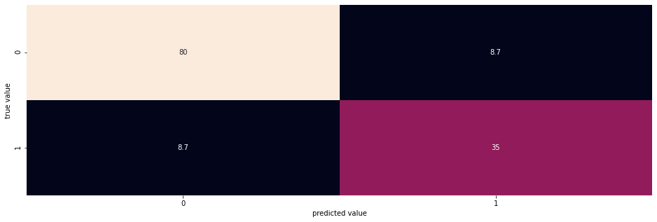

```
+------------+----------+-------------+
|   accuracy |   recall |   precision |
+============+==========+=============+
|   0.868398 | 0.851097 |    0.851617 |
+------------+----------+-------------+
```

```python
# results: confusion matrix
ma9 = sum(cm_holder9)/3
plt.figure(figsize = (16,5))
sns.heatmap(ma9,square= False, annot=True, cbar= False)
plt.xlabel("predicted value")
plt.ylabel("true value")
plt.show()

# results: accuracy
accuracy9 = statistics.mean(accscores9)

# results: sensitivity(recall)
recall9 = statistics.mean(recscores9)

# results: precision
precision9 = statistics.mean(prescores9)

# draw table with accuracy, recall, precision
data9 = [[accuracy9, recall9, precision9]]

headers = ["accuracy", "recall", "precision"]

print(tabulate(data9, headers= headers, tablefmt= "grid"))
```

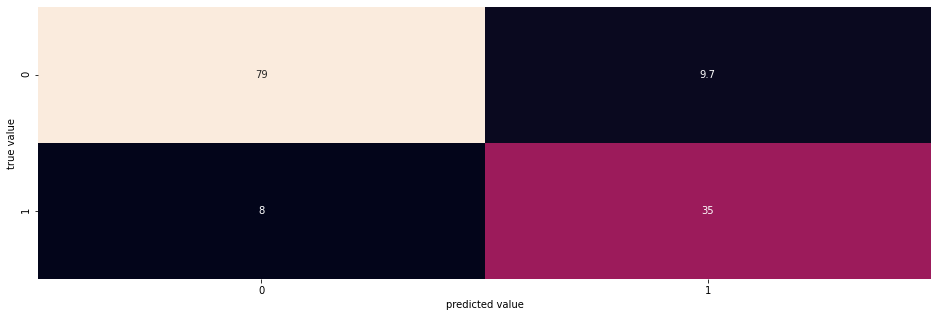

```
+------------+----------+-------------+
|   accuracy |   recall |   precision |
+============+==========+=============+
|   0.865853 | 0.853189 |    0.847281 |
+------------+----------+-------------+
```

```python
# results: confusion matrix
ma10 = sum(cm_holder10)/3
plt.figure(figsize = (16,5))
sns.heatmap(ma10,square= False, annot=True, cbar= False)
plt.xlabel("predicted value")
plt.ylabel("true value")
plt.show()

# results: accuracy
accuracy10 = statistics.mean(accscores10)

# results: sensitivity(recall)
recall10 = statistics.mean(recscores10)

# results: precision
precision10 = statistics.mean(prescores10)

# draw table with accuracy, recall, precision
data10 = [[accuracy10, recall10, precision10]]

headers = ["accuracy", "recall", "precision"]

print(tabulate(data10, headers= headers, tablefmt= "grid"))
```

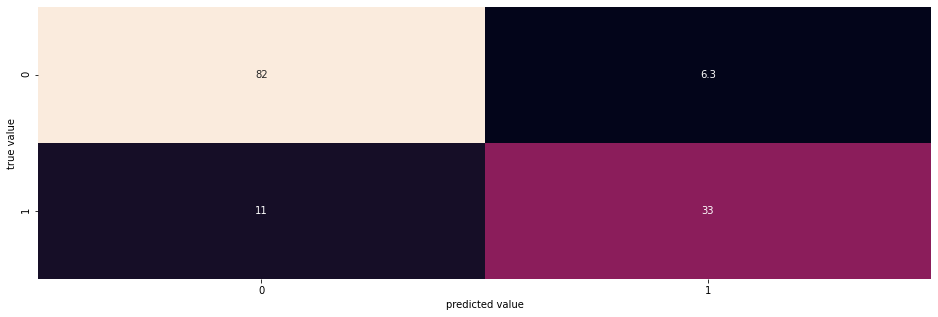

```
+------------+----------+-------------+
|   accuracy |   recall |   precision |
+============+==========+=============+
|   0.870846 | 0.841081 |    0.861279 |
+------------+----------+-------------+
```

```python
# results: confusion matrix
ma11 = sum(cm_holder11)/3
plt.figure(figsize = (16,5))
sns.heatmap(ma11,square= False, annot=True, cbar= False)
plt.xlabel("predicted value")
plt.ylabel("true value")
plt.show()

# results: accuracy
accuracy11 = statistics.mean(accscores11)

# results: sensitivity(recall)
recall11 = statistics.mean(recscores11)

# results: precision
precision11 = statistics.mean(prescores11)

# draw table with accuracy, recall, precision
data11 = [[accuracy11, recall11, precision11]]

headers = ["accuracy", "recall", "precision"]

print(tabulate(data11, headers= headers, tablefmt= "grid"))
```

## Model Construction: KNN without PCA for 5-level classification

```python
KNNNPCA5_model2 = KNeighborsClassifier(n_neighbors=5)
KNNNPCA10_model2 = KNeighborsClassifier(n_neighbors=10)
KNNNPCA15_model2 = KNeighborsClassifier(n_neighbors=15)
```

```python
folds = StratifiedKFold(n_splits=3)

accscores12 = []
recscores12 = []
prescores12 = []
cm_holder12 = []

accscores13 = []
recscores13 = []
prescores13 = []
cm_holder13 = []

accscores14 = []
recscores14 = []
prescores14 = []
cm_holder14 = []

for train_index, test_index in folds.split(X,five_level_y):
    X_train, X_test, y_train, y_test = X.iloc[train_index], X.iloc[test_index], \
                                       five_level_y.iloc[train_index], five_level_y.iloc[test_index]
    # test model
    KNNNPCA5_model2.fit(X_train, y_train)
    y_predict = KNNNPCA5_model2.predict(X_test)
    cm_holder12.append(confusion_matrix(y_test, y_predict, labels = five_level_label))
    accscores12.append(accuracy_score(y_test, y_predict))
    recscores12.append(recall_score(y_test, y_predict, average='macro'))
    prescores12.append(precision_score(y_test, y_predict, average='macro'))

    KNNNPCA10_model2.fit(X_train, y_train)
    y_predict = KNNNPCA10_model2.predict(X_test)
    cm_holder13.append(confusion_matrix(y_test, y_predict, labels = five_level_label))
    accscores13.append(accuracy_score(y_test, y_predict))
    recscores13.append(recall_score(y_test, y_predict, average='macro'))
    prescores13.append(precision_score(y_test, y_predict, average='macro'))

    KNNNPCA15_model2.fit(X_train, y_train)
    y_predict = KNNNPCA15_model2.predict(X_test)
    cm_holder14.append(confusion_matrix(y_test, y_predict, labels = five_level_label))
    accscores14.append(accuracy_score(y_test, y_predict))
    recscores14.append(recall_score(y_test, y_predict, average='macro'))
    prescores14.append(precision_score(y_test, y_predict, average='macro'))
```

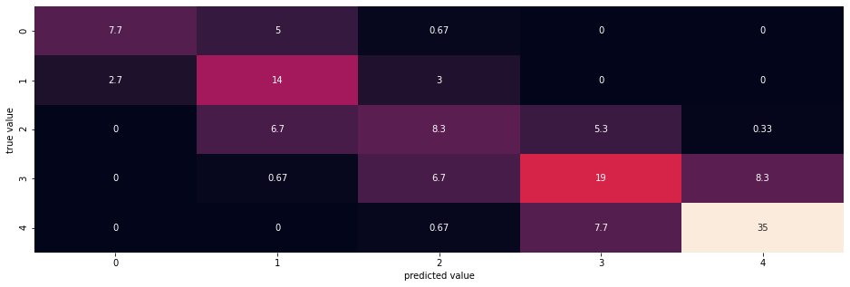

```
+------------+----------+-------------+
|   accuracy |   recall |   precision |
+============+==========+=============+
|   0.637983 |  0.61028 |     0.62061 |
+------------+----------+-------------+
```

```python
# results: confusion matrix
ma12 = sum(cm_holder12)/3
plt.figure(figsize = (16,5))
sns.heatmap(ma12,square= False, annot=True, cbar= False)
plt.xlabel("predicted value")
plt.ylabel("true value")
plt.show()

# results: accuracy
accuracy12 = statistics.mean(accscores12)

# results: sensitivity(recall)
recall12 = statistics.mean(recscores12)

# results: precision
precision12 = statistics.mean(prescores12)

# draw table with accuracy, recall, precision
data12 = [[accuracy12, recall12, precision12]]

headers = ["accuracy", "recall", "precision"]

print(tabulate(data12, headers= headers, tablefmt= "grid"))
```

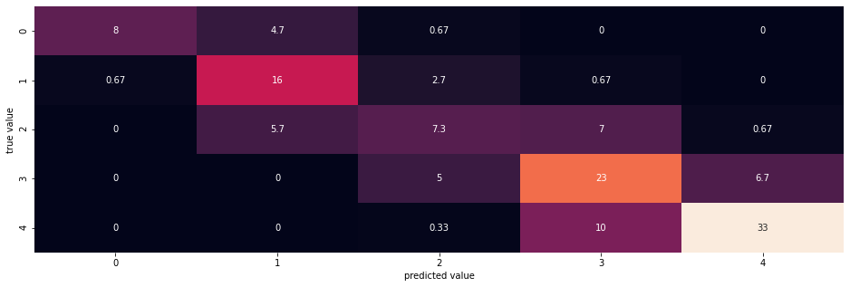

```
+------------+----------+-------------+
|   accuracy |   recall |   precision |
+============+==========+=============+
|   0.658262 | 0.634789 |    0.678228 |
+------------+----------+-------------+
```

```python
# results: confusion matrix
ma13 = sum(cm_holder13)/3
plt.figure(figsize = (16,5))
sns.heatmap(ma13,square= False, annot=True, cbar= False)
plt.xlabel("predicted value")
plt.ylabel("true value")
plt.show()

# results: accuracy
accuracy13 = statistics.mean(accscores13)

# results: sensitivity(recall)
recall13 = statistics.mean(recscores13)

# results: precision
precision13 = statistics.mean(prescores13)

# draw table with accuracy, recall, precision
data13 = [[accuracy13, recall13, precision13]]

headers = ["accuracy", "recall", "precision"]

print(tabulate(data13, headers= headers, tablefmt= "grid"))
```

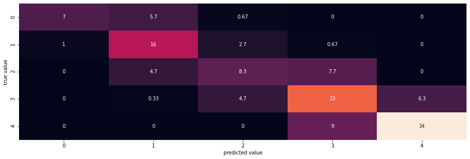

```
+------------+----------+-------------+
|   accuracy |   recall |   precision |
+============+==========+=============+
|   0.670946 | 0.635284 |    0.679958 |
+------------+----------+-------------+
```

```python
# results: confusion matrix
ma14 = sum(cm_holder14)/3
plt.figure(figsize = (16,5))
sns.heatmap(ma14,square= False, annot=True, cbar= False)
plt.xlabel("predicted value")
plt.ylabel("true value")
plt.show()

# results: accuracy
accuracy14 = statistics.mean(accscores14)

# results: sensitivity(recall)
recall14 = statistics.mean(recscores14)

# results: precision
precision14 = statistics.mean(prescores14)

# draw table with accuracy, recall, precision
data14 = [[accuracy14, recall14, precision14]]

headers = ["accuracy", "recall", "precision"]

print(tabulate(data14, headers= headers, tablefmt= "grid"))
```

## Model Construction: Decision Tree with PCA for binary classification

```python
DecisionTreePCA_model=tree.DecisionTreeClassifier()
```

```python
from sklearn.preprocessing import StandardScaler
from sklearn.decomposition import PCA


folds = StratifiedKFold(n_splits=3)

accscores15 = []
recscores15 = []
prescores15 = []

cm_holder15 = []


scaler = StandardScaler()

for train_index, test_index in folds.split(X,binary_y):
    X_train, X_test, y_train, y_test = X.iloc[train_index], X.iloc[test_index], \
                                       binary_y.iloc[train_index], binary_y.iloc[test_index]

    # Fit on training set only.
    scaler.fit(X_train)

    # Apply transform to both the training set and the test set.
    X_train = scaler.transform(X_train)
    X_test = scaler.transform(X_test)

    # Make an instance of the Model
    pca=PCA(n_components='mle')

    # fitting PCA on the training set only.
    pca.fit(X_train)

    # dimensional reduction
    X_train = pca.transform(X_train)
    X_test = pca.transform(X_test)

    # test model
    DecisionTreePCA_model.fit(X_train, y_train)
    y_predict = DecisionTreePCA_model.predict(X_test)
    cm_holder15.append(confusion_matrix(y_test, y_predict, labels = binary_label))
    accscores15.append(accuracy_score(y_test, y_predict))
    recscores15.append(recall_score(y_test, y_predict, average='macro'))
    prescores15.append(precision_score(y_test, y_predict, average='macro'))
```

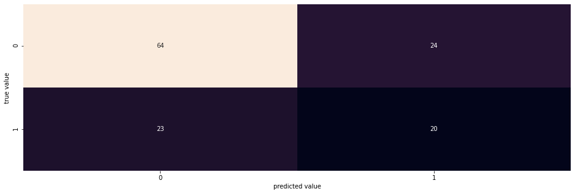

```
+------------+----------+-------------+
|   accuracy |   recall |   precision |
+============+==========+=============+
|   0.637925 | 0.593596 |    0.591898 |
+------------+----------+-------------+
```

```python
# results: confusion matrix
ma15 = sum(cm_holder15)/3
plt.figure(figsize = (16,5))
sns.heatmap(ma15,square= False, annot=True, cbar= False)
plt.xlabel("predicted value")
plt.ylabel("true value")
plt.show()

# results: accuracy
accuracy15 = statistics.mean(accscores15)

# results: sensitivity(recall)
recall15 = statistics.mean(recscores15)

# results: precision
precision15 = statistics.mean(prescores15)

# draw table with accuracy, recall, precision
data15 = [[accuracy15, recall15, precision15]]

headers = ["accuracy", "recall", "precision"]

print(tabulate(data15, headers= headers, tablefmt= "grid"))
```

## Model Construction: Decision Tree with PCA for 5-level classification

```python
DecisionTreePCA_model2=tree.DecisionTreeClassifier()
```

```python
folds = StratifiedKFold(n_splits=3)

five_level_label = ["A", "B", "C", "D", "F"]

accscores16 = []
recscores16 = []
prescores16 = []

cm_holder16 = []

for train_index, test_index in folds.split(X,five_level_y):
    X_train, X_test, y_train, y_test = X.iloc[train_index], X.iloc[test_index], \
                                       five_level_y.iloc[train_index], five_level_y.iloc[test_index]

    # Fit on training set only.
    scaler.fit(X_train)

    # Apply transform to both the training set and the test set.
    X_train = scaler.transform(X_train)
    X_test = scaler.transform(X_test)

    # Make an instance of the Model
    pca=PCA(n_components='mle')

    # fitting PCA on the training set only.
    pca.fit(X_train)

    # dimensional reduction
    X_train = pca.transform(X_train)
    X_test = pca.transform(X_test)

    # test model
    DecisionTreePCA_model2.fit(X_train, y_train)
    y_predict = DecisionTreePCA_model2.predict(X_test)
    cm_holder16.append(confusion_matrix(y_test, y_predict, labels = five_level_label))
    accscores16.append(accuracy_score(y_test, y_predict))
    recscores16.append(recall_score(y_test, y_predict, average='macro'))
    prescores16.append(precision_score(y_test, y_predict, average='macro'))
```

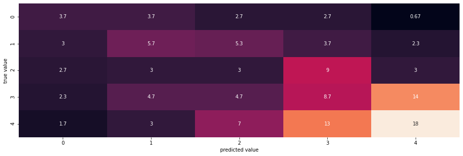

```
+------------+----------+-------------+
|   accuracy |   recall |   precision |
+============+==========+=============+
|   0.298809 | 0.276512 |     0.27862 |
+------------+----------+-------------+
```

```python
# results: confusion matrix
ma16 = sum(cm_holder16)/3
plt.figure(figsize = (16,5))
sns.heatmap(ma16,square= False, annot=True, cbar= False)
plt.xlabel("predicted value")
plt.ylabel("true value")
plt.show()

# results: accuracy
accuracy16 = statistics.mean(accscores16)

# results: sensitivity(recall)
recall16 = statistics.mean(recscores16)

# results: precision
precision16 = statistics.mean(prescores16)

# draw table with accuracy, recall, precision
data16 = [[accuracy16, recall16, precision16]]

headers = ["accuracy", "recall", "precision"]

print(tabulate(data16, headers= headers, tablefmt= "grid"))
```

## Model Construction: Random Forest with PCA for binary classification

```python
RandomForestPCA100_model=ensemble.RandomForestClassifier(n_estimators = 100)
```

```python
folds = StratifiedKFold(n_splits=3)

accscores17 = []
recscores17 = []
prescores17 = []
cm_holder17 = []


for train_index, test_index in folds.split(X,binary_y):
    X_train, X_test, y_train, y_test = X.iloc[train_index], X.iloc[test_index], \
                                       binary_y.iloc[train_index], binary_y.iloc[test_index]

    # Fit on training set only.
    scaler.fit(X_train)

    # Apply transform to both the training set and the test set.
    X_train = scaler.transform(X_train)
    X_test = scaler.transform(X_test)

    # Make an instance of the Model
    pca=PCA(n_components='mle')

    # fitting PCA on the training set only.
    pca.fit(X_train)

    # dimensional reduction
    X_train = pca.transform(X_train)
    X_test = pca.transform(X_test)

    # test model
    RandomForestPCA100_model.fit(X_train, y_train)
    y_predict = RandomForestPCA100_model.predict(X_test)
    cm_holder17.append(confusion_matrix(y_test, y_predict, labels = binary_label))
    accscores17.append(accuracy_score(y_test, y_predict))
    recscores17.append(recall_score(y_test, y_predict, average='macro'))
    prescores17.append(precision_score(y_test, y_predict, average='macro'))
```

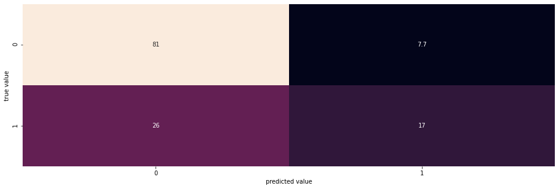

```
+------------+----------+-------------+
|   accuracy |   recall |   precision |
+============+==========+=============+
|   0.741692 |  0.65316 |    0.724957 |
+------------+----------+-------------+
```

```python
# results: confusion matrix
ma17 = sum(cm_holder17)/3
plt.figure(figsize = (16,5))
sns.heatmap(ma17,square= False, annot=True, cbar= False)
plt.xlabel("predicted value")
plt.ylabel("true value")
plt.show()

# results: accuracy
accuracy17 = statistics.mean(accscores17)

# results: sensitivity(recall)
recall17 = statistics.mean(recscores17)

# results: precision
precision17 = statistics.mean(prescores17)

# draw table with accuracy, recall, precision
data17 = [[accuracy17, recall17, precision17]]

headers = ["accuracy", "recall", "precision"]

print(tabulate(data17, headers= headers, tablefmt= "grid"))
```

## Model Construction: Random Forest with PCA for 5-level classification

```python
RandomForestPCA100_model2=ensemble.RandomForestClassifier(n_estimators = 100)
```

```python
folds = StratifiedKFold(n_splits=3)

accscores18 = []
recscores18 = []
prescores18 = []
cm_holder18 = []

for train_index, test_index in folds.split(X,five_level_y):
    X_train, X_test, y_train, y_test = X.iloc[train_index], X.iloc[test_index], \
                                       five_level_y.iloc[train_index], five_level_y.iloc[test_index]

    # Fit on training set only.
    scaler.fit(X_train)

    # Apply transform to both the training set and the test set.
    X_train = scaler.transform(X_train)
    X_test = scaler.transform(X_test)

    # Make an instance of the Model
    pca=PCA(n_components='mle')

    # fitting PCA on the training set only.
    pca.fit(X_train)

    # dimensional reduction
    X_train = pca.transform(X_train)
    X_test = pca.transform(X_test)

    # test model
    RandomForestPCA100_model2.fit(X_train, y_train)
    y_predict = RandomForestPCA100_model2.predict(X_test)
    cm_holder18.append(confusion_matrix(y_test, y_predict, labels = five_level_label))
    accscores18.append(accuracy_score(y_test, y_predict))
    recscores18.append(recall_score(y_test, y_predict, average='macro'))
    prescores18.append(precision_score(y_test, y_predict, average='macro'))
```

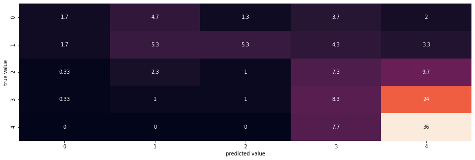

```
+------------+----------+-------------+
|   accuracy |   recall |   precision |
+============+==========+=============+
|   0.395038 | 0.301376 |     0.30589 |
+------------+----------+-------------+
```

```python
# results: confusion matrix
ma18 = sum(cm_holder18)/3
plt.figure(figsize = (16,5))
sns.heatmap(ma18,square= False, annot=True, cbar= False)
plt.xlabel("predicted value")
plt.ylabel("true value")
plt.show()

# results: accuracy
accuracy18 = statistics.mean(accscores18)

# results: sensitivity(recall)
recall18 = statistics.mean(recscores18)

# results: precision
precision18 = statistics.mean(prescores18)

# draw table with accuracy, recall, precision
data18 = [[accuracy18, recall18, precision18]]

headers = ["accuracy", "recall", "precision"]

print(tabulate(data18, headers= headers, tablefmt= "grid"))
```

## Model Construction: KNN with PCA for binary classification

```python
KNNPCA10_model = KNeighborsClassifier(n_neighbors=10)
```

```python
folds = StratifiedKFold(n_splits=3)

accscores19 = []
recscores19 = []
prescores19 = []
cm_holder19 = []

for train_index, test_index in folds.split(X,binary_y):
    X_train, X_test, y_train, y_test = X.iloc[train_index], X.iloc[test_index], \
                                       binary_y.iloc[train_index], binary_y.iloc[test_index]

    # Fit on training set only.
    scaler.fit(X_train)

    # Apply transform to both the training set and the test set.
    X_train = scaler.transform(X_train)
    X_test = scaler.transform(X_test)

    # Make an instance of the Model
    pca=PCA(n_components='mle')

    # fitting PCA on the training set only.
    pca.fit(X_train)

    # dimensional reduction
    X_train = pca.transform(X_train)
    X_test = pca.transform(X_test)

    # test model
    KNNPCA10_model.fit(X_train, y_train)
    y_predict = KNNPCA10_model.predict(X_test)
    cm_holder19.append(confusion_matrix(y_test, y_predict, labels = binary_label))
    accscores19.append(accuracy_score(y_test, y_predict))
    recscores19.append(recall_score(y_test, y_predict, average='macro'))
    prescores19.append(precision_score(y_test, y_predict, average='macro'))
```

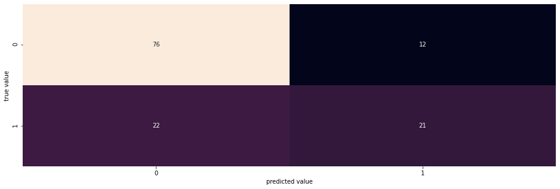

```
+------------+----------+-------------+
|   accuracy |   recall |   precision |
+============+==========+=============+
|   0.736776 | 0.672734 |    0.701407 |
+------------+----------+-------------+
```

```python
# results: confusion matrix
ma19 = sum(cm_holder19)/3
plt.figure(figsize = (16,5))
sns.heatmap(ma19,square= False, annot=True, cbar= False)
plt.xlabel("predicted value")
plt.ylabel("true value")
plt.show()

# results: accuracy
accuracy19 = statistics.mean(accscores19)

# results: sensitivity(recall)
recall19 = statistics.mean(recscores19)

# results: precision
precision19 = statistics.mean(prescores19)

# draw table with accuracy, recall, precision
data19 = [[accuracy19, recall19, precision19]]

headers = ["accuracy", "recall", "precision"]

print(tabulate(data19, headers= headers, tablefmt= "grid"))
```

## Model Construction: KNN with PCA for 5-level classification

```python
KNNPCA10_model2 = KNeighborsClassifier(n_neighbors=10)
```

```python
folds = StratifiedKFold(n_splits=3)

accscores20 = []
recscores20 = []
prescores20 = []
cm_holder20 = []

for train_index, test_index in folds.split(X,five_level_y):
    X_train, X_test, y_train, y_test = X.iloc[train_index], X.iloc[test_index], \
                                       five_level_y.iloc[train_index], five_level_y.iloc[test_index]

    # Fit on training set only.
    scaler.fit(X_train)

    # Apply transform to both the training set and the test set.
    X_train = scaler.transform(X_train)
    X_test = scaler.transform(X_test)

    # Make an instance of the Model
    pca=PCA(n_components='mle')

    # fitting PCA on the training set only.
    pca.fit(X_train)

    # dimensional reduction
    X_train = pca.transform(X_train)
    X_test = pca.transform(X_test)

    # test model
    KNNPCA10_model2.fit(X_train, y_train)
    y_predict = KNNPCA10_model2.predict(X_test)
    cm_holder20.append(confusion_matrix(y_test, y_predict, labels = five_level_label))
    accscores20.append(accuracy_score(y_test, y_predict))
    recscores20.append(recall_score(y_test, y_predict, average='macro'))
    prescores20.append(precision_score(y_test, y_predict, average='macro'))
```

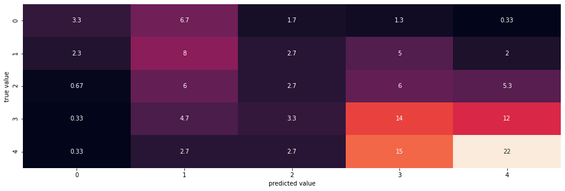

```
+------------+----------+-------------+
|   accuracy |   recall |   precision |
+============+==========+=============+
|   0.379829 | 0.337972 |    0.357295 |
+------------+----------+-------------+
```

```python
# results: confusion matrix
ma20 = sum(cm_holder20)/3
plt.figure(figsize = (16,5))
sns.heatmap(ma20,square= False, annot=True, cbar= False)
plt.xlabel("predicted value")
plt.ylabel("true value")
plt.show()

# results: accuracy
accuracy20 = statistics.mean(accscores20)

# results: sensitivity(recall)
recall20 = statistics.mean(recscores20)

# results: precision
precision20 = statistics.mean(prescores20)

# draw table with accuracy, recall, precision
data20 = [[accuracy20, recall20, precision20]]

headers = ["accuracy", "recall", "precision"]

print(tabulate(data20, headers= headers, tablefmt= "grid"))
```

## Compare & Conclusion: Compare the results with/without PCA

```python
from prettytable import PrettyTable

table = PrettyTable()

class color:
    PURPLE = '\033[95m'
    CYAN = '\033[96m'
    DARKCYAN = '\033[36m'
    BLUE = '\033[94m'
    GREEN = '\033[92m'
    YELLOW = '\033[93m'
    RED = '\033[91m'
    BOLD = '\033[1m'
    UNDERLINE = '\033[4m'
    END = '\033[0m'

table.title = color.BOLD +'Decision tree with/without PCA for binary classification'+color.END
table.field_names = ['',color.BOLD +color.GREEN+'without PCA', 'with PCA' + color.END + color.END]
table.add_row([color.BOLD +color.BLUE+'accuracy'+color.END+color.END, accuracy, accuracy15])
table.add_row([color.BOLD +color.BLUE+'recall'+color.END+color.END, recall, recall15])
table.add_row([color.BOLD +color.BLUE+'precision'+color.END+color.END, precision, precision15])

print(table)

table.clear_rows()

table.title = color.BOLD +'Decision tree with/without PCA for 5-level classification'+color.END
table.add_row([color.BOLD +color.BLUE+'accuracy'+color.END+color.END, accuracy2, accuracy16])
table.add_row([color.BOLD +color.BLUE+'recall'+color.END+color.END, recall2, recall16])
table.add_row([color.BOLD +color.BLUE+'precision'+color.END+color.END, precision2, precision16])

print(table)

table.clear_rows()
table.title = color.BOLD +'Random forest with/without PCA for binary classification'+color.END
table.add_row([color.BOLD +color.BLUE+'accuracy'+color.END+color.END, accuracy4, accuracy17])
table.add_row([color.BOLD +color.BLUE+'recall'+color.END+color.END, recall4, recall17])
table.add_row([color.BOLD +color.BLUE+'precision'+color.END+color.END, precision4, precision17])

print(table)

table.clear_rows()
table.title = color.BOLD +'Random forest with/without PCA for 5-level classification'+color.END
table.add_row([color.BOLD +color.BLUE+'accuracy'+color.END+color.END, accuracy7, accuracy18])
table.add_row([color.BOLD +color.BLUE+'recall'+color.END+color.END, recall7, recall18])
table.add_row([color.BOLD +color.BLUE+'precision'+color.END+color.END, precision7, precision18])

print(table)

table.clear_rows()
table.title = color.BOLD +'KNN with/without PCA for binary classification'+color.END
table.add_row([color.BOLD +color.BLUE+'accuracy'+color.END+color.END, accuracy10, accuracy19])
table.add_row([color.BOLD +color.BLUE+'recall'+color.END+color.END, recall10, recall19])
table.add_row([color.BOLD +color.BLUE+'precision'+color.END+color.END, precision10, precision19])

print(table)

table.clear_rows()
table.title = color.BOLD +'KNN with/without PCA for 5-level classification'+color.END
table.add_row([color.BOLD +color.BLUE+'accuracy'+color.END+color.END, accuracy13, accuracy20])
table.add_row([color.BOLD +color.BLUE+'recall'+color.END+color.END, recall13, recall20])
table.add_row([color.BOLD +color.BLUE+'precision'+color.END+color.END, precision13, precision20])

print(table)
```

```
+--------------------------------------------------------------------+
|      Decision tree with/without PCA for binary classification      |
+--------------+--------------------------+--------------------------+
|              |       without PCA        |         with PCA         |
+--------------+--------------------------+--------------------------+
|   accuracy   |    0.8531112653250058    |    0.6379250520471894    |
|    recall    |    0.8355509299950116    |    0.5935963370311423    |
|  precision   |    0.8337047593419408    |    0.5918980644444269    |
+--------------+--------------------------+--------------------------+
+--------------------------------------------------------------------+
|     Decision tree with/without PCA for 5-level classification      |
+--------------+--------------------------+--------------------------+
|              |       without PCA        |         with PCA         |
+--------------+--------------------------+--------------------------+
|   accuracy   |    0.6099352301642378    |    0.2988086976636595    |
|    recall    |    0.5883082262015231    |    0.276512382586254     |
|  precision   |    0.5867900484194535    |    0.2786204052046548    |
+--------------+--------------------------+--------------------------+
+--------------------------------------------------------------------+
|      Random forest with/without PCA for binary classification      |
+--------------+--------------------------+--------------------------+
|              |       without PCA        |         with PCA         |
+--------------+--------------------------+--------------------------+
|   accuracy   |    0.8987200246742232    |    0.7416917264245508    |
|    recall    |    0.8832730558788829    |    0.6531601618484294    |
|  precision   |    0.8886166958288361    |    0.7249566202609017    |
+--------------+--------------------------+--------------------------+
+--------------------------------------------------------------------+
|     Random forest with/without PCA for 5-level classification      |
+--------------+-------------------------+---------------------------+
|              |       without PCA       |          with PCA         |
+--------------+-------------------------+---------------------------+
|   accuracy   |    0.6609029223533041   |     0.3950381679389313    |
|    recall    |    0.6110712026991096   |    0.30137595646487575    |
|  precision   |    0.6458956844468524   |    0.30589045689894584    |
+--------------+-------------------------+---------------------------+
+----------------------------------------------------------+
|      KNN with/without PCA for binary classification      |
+------------+----------------------+----------------------+
|            |     without PCA      |       with PCA       |
+------------+----------------------+----------------------+
|  accuracy  |  0.8658531883722723  |  0.7367761585318837  |
|   recall   |   0.85318876642041   |  0.6727344981035862  |
| precision  |  0.8472806693736926  |  0.7014072295584901  |
+------------+----------------------+----------------------+
+-----------------------------------------------------------+
|      KNN with/without PCA for 5-level classification      |
+------------+----------------------+-----------------------+
|            |     without PCA      |        with PCA       |
+------------+----------------------+-----------------------+
|  accuracy  |  0.6582620094070476  |   0.3798288225769142  |
|   recall   |  0.6347894573886366  |  0.33797197938100815  |
| precision  |  0.6782277246594456  |  0.35729534762673776  |
+------------+----------------------+-----------------------+
```

從上圖的表來看，PCA對model的performance影響巨大，我們可以分項比較without PCA和with PCA的表現：

- 在相同model下：有PCA時performance皆呈現下降趨勢，而對於有更多label的5-level classification來說，下降的趨勢更劇烈
- 在不同model下：受影響的程度Decision tree > Random forest > KNN, 而performance則是Recall > Precision > Accuracy

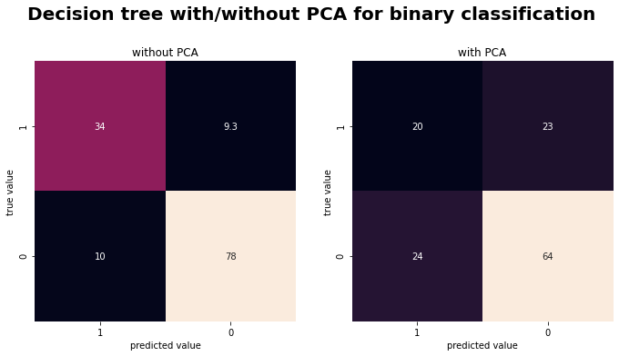

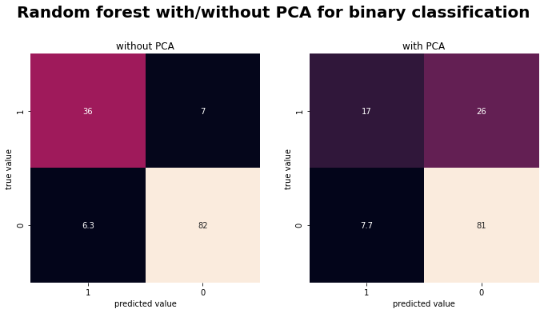

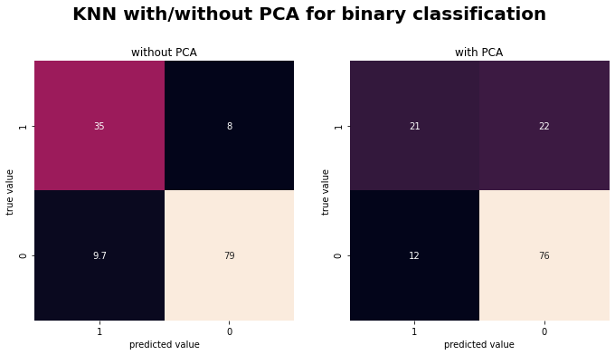

```python
# Build subplot
fig, axes = plt.subplots(2, 2)
fig.set_figheight(10)
fig.set_figwidth(10)
fig.suptitle('Decision tree with/without PCA for binary classification', fontweight="bold", size=20)

sns.heatmap(ma,square= True, annot=True, cbar= False, ax = axes[0][0])
axes[0, 0].set_title('without PCA')
axes[0, 0].invert_xaxis()
axes[0, 0].invert_yaxis()


sns.heatmap(ma15,square= True, annot=True, cbar= False, ax = axes[0][1])
axes[0, 1].set_title('with PCA')
axes[0, 1].invert_xaxis()
axes[0, 1].invert_yaxis()

# name x and y axis
plt.setp(axes[:, :], xlabel='predicted value')
plt.setp(axes[:, :], ylabel='true value')

# delete extra plot
fig.delaxes(axes[1][0])
fig.delaxes(axes[1][1])

# print out the subplot
plt.tight_layout(pad=2)


# Build subplot
fig, axes = plt.subplots(2, 2)
fig.set_figheight(10)
fig.set_figwidth(10)
fig.suptitle('Random forest with/without PCA for binary classification', fontweight="bold", size=20)

sns.heatmap(ma4,square= True, annot=True, cbar= False, ax = axes[0][0])
axes[0, 0].set_title('without PCA')
axes[0, 0].invert_xaxis()
axes[0, 0].invert_yaxis()


sns.heatmap(ma17,square= True, annot=True, cbar= False, ax = axes[0][1])
axes[0, 1].set_title('with PCA')
axes[0, 1].invert_xaxis()
axes[0, 1].invert_yaxis()

# name x and y axis
plt.setp(axes[:, :], xlabel='predicted value')
plt.setp(axes[:, :], ylabel='true value')

# delete extra plot
fig.delaxes(axes[1][0])
fig.delaxes(axes[1][1])

# print out the subplot
plt.tight_layout(pad=2)


# Build subplot
fig, axes = plt.subplots(2, 2)
fig.set_figheight(10)
fig.set_figwidth(10)
fig.suptitle('KNN with/without PCA for binary classification', fontweight="bold", size=20)

sns.heatmap(ma10,square= True, annot=True, cbar= False, ax = axes[0][0])
axes[0, 0].set_title('without PCA')
axes[0, 0].invert_xaxis()
axes[0, 0].invert_yaxis()


sns.heatmap(ma19,square= True, annot=True, cbar= False, ax = axes[0][1])
axes[0, 1].set_title('with PCA')
axes[0, 1].invert_xaxis()
axes[0, 1].invert_yaxis()

# name x and y axis
plt.setp(axes[:, :], xlabel='predicted value')
plt.setp(axes[:, :], ylabel='true value')

# delete extra plot
fig.delaxes(axes[1][0])
fig.delaxes(axes[1][1])

# print out the subplot
plt.tight_layout(pad=2)
```

從上圖的表來看，對binary classification來說，PCA對confusion matrix的影響不如accuracy, recall, precision來的劇烈，我們可以分項比較without PCA和with PCA的表現：

- True positive & True negative: PCA對true positive的影響比true negative來的更大，並且數值都是往下降的。然而對true negative的影響似乎較沒有太大的影響，在random forest時數值甚至將近持平
- False positive & False negative: 在三個例子中false positive & false negative皆提升，false negative相較浮動較大

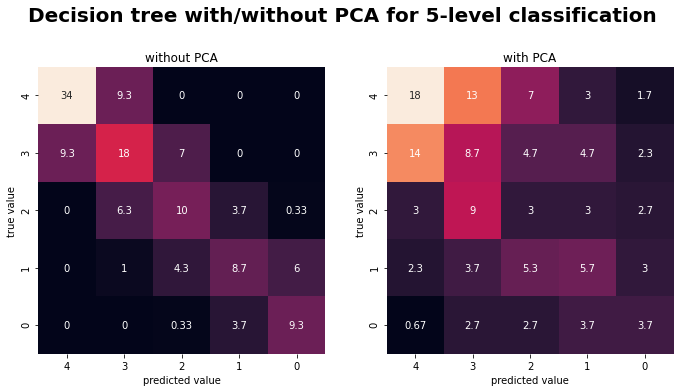

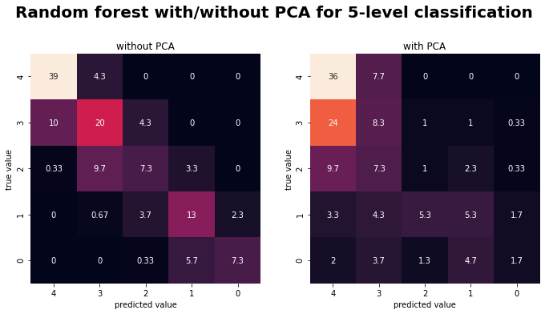

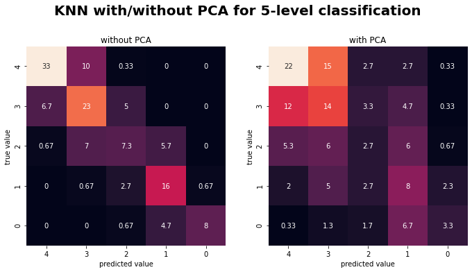

```python
# Build subplot
fig, axes = plt.subplots(2, 2)
fig.set_figheight(10)
fig.set_figwidth(10)
fig.suptitle('Decision tree with/without PCA for 5-level classification', fontweight="bold", size=20)

sns.heatmap(ma2,square= True, annot=True, cbar= False, ax = axes[0][0])
axes[0, 0].set_title('without PCA')
axes[0, 0].invert_xaxis()
axes[0, 0].invert_yaxis()


sns.heatmap(ma16,square= True, annot=True, cbar= False, ax = axes[0][1])
axes[0, 1].set_title('with PCA')
axes[0, 1].invert_xaxis()
axes[0, 1].invert_yaxis()

# name x and y axis
plt.setp(axes[:, :], xlabel='predicted value')
plt.setp(axes[:, :], ylabel='true value')

# delete extra plot
fig.delaxes(axes[1][0])
fig.delaxes(axes[1][1])

# print out the subplot
plt.tight_layout(pad=2)


# Build subplot
fig, axes = plt.subplots(2, 2)
fig.set_figheight(10)
fig.set_figwidth(10)
fig.suptitle('Random forest with/without PCA for 5-level classification', fontweight="bold", size=20)

sns.heatmap(ma7,square= True, annot=True, cbar= False, ax = axes[0][0])
axes[0, 0].set_title('without PCA')
axes[0, 0].invert_xaxis()
axes[0, 0].invert_yaxis()


sns.heatmap(ma18,square= True, annot=True, cbar= False, ax = axes[0][1])
axes[0, 1].set_title('with PCA')
axes[0, 1].invert_xaxis()
axes[0, 1].invert_yaxis()

# name x and y axis
plt.setp(axes[:, :], xlabel='predicted value')
plt.setp(axes[:, :], ylabel='true value')

# delete extra plot
fig.delaxes(axes[1][0])
fig.delaxes(axes[1][1])

# print out the subplot
plt.tight_layout(pad=2)


# Build subplot
fig, axes = plt.subplots(2, 2)
fig.set_figheight(10)
fig.set_figwidth(10)
fig.suptitle('KNN with/without PCA for 5-level classification', fontweight="bold", size=20)

sns.heatmap(ma13,square= True, annot=True, cbar= False, ax = axes[0][0])
axes[0, 0].set_title('without PCA')
axes[0, 0].invert_xaxis()
axes[0, 0].invert_yaxis()


sns.heatmap(ma20,square= True, annot=True, cbar= False, ax = axes[0][1])
axes[0, 1].set_title('with PCA')
axes[0, 1].invert_xaxis()
axes[0, 1].invert_yaxis()

# name x and y axis
plt.setp(axes[:, :], xlabel='predicted value')
plt.setp(axes[:, :], ylabel='true value')

# delete extra plot
fig.delaxes(axes[1][0])
fig.delaxes(axes[1][1])

# print out the subplot
plt.tight_layout(pad=2)
```

從上圖的confusion matrix來看，和binary classification相似，PCA同樣對confusion matrix的影響不如accuracy, recall, precision來的劇烈，而我們也能觀察到，在執行PCA後confusion matrix整體變得更加分散，而此三個model的整體數值也更偏向左上角，推測原因是給定的data set中G3 = F比其他的的資料點多，因此更能精準判斷G3 = F，不受簡化的特徵影響。

## Questions

### Decision Tree: Show the prediction and reasoning of one arbitrary sample in the testing set.

```python
fig = plt.figure(figsize=(70,50))
_ = tree.plot_tree(DecisionTreeNPCA_model,
                   feature_names=mat.columns,
                   class_names=['pass','fail'],
                   filled=True,
                   fontsize = 30,
                   impurity = False)
fig.savefig('decisiontree.png', bbox_inches='tight')
plt.close(fig)
```

[figure not shown]

```python
from PIL import Image

Image.open('decisiontree.jpeg')
```

### Describe the difference between boosting and bagging

Both used in esemble learning, there are different in three categories

- How to make classification
  - Boosting: Making a lot of 'weak learners'(usually stumps = root with only two leaves), and do classification with these
  - Bagging: Making a lot of trees, and do classification with them
- Voting
  - Boosting: Uses weighed voting, stumps may have different weights
  - Bagging: Uses normal voting, every tree has equal say
- Relations in between
  - Boosting: The stump order matters in boosting, since each stump take in account of the previous stump's mistake
  - Bagging: Every tree is independent

### KNN: Show the prediction and reasoning of one arbitrary sample in the testing set.

```python
closest_distances, indices = KNNNPCA10_model.kneighbors(X.loc[0].values.reshape(1, -1), n_neighbors = 10)

closest_distances = closest_distances.flatten()
indices = indices.flatten()
#print(indices)
i = 0
for elements in range(10):
    idx = indices[i]
    print('label: ', binary_y.iloc[idx].values)
    print('distance: ', closest_distances[i])
    i +=1

print('prediction: ', KNNNPCA10_model.predict(X.loc[0].values.reshape(1, -1)))
```

```
label:  ['fail']
distance:  0.0
label:  ['fail']
distance:  4.123105625617661
label:  ['fail']
distance:  6.0
label:  ['fail']
distance:  6.0
label:  ['fail']
distance:  6.082762530298219
label:  ['fail']
distance:  6.244997998398398
label:  ['fail']
distance:  6.324555320336759
label:  ['pass']
distance:  6.4031242374328485
label:  ['fail']
distance:  6.48074069840786
label:  ['fail']
distance:  6.708203932499369
prediction:  ['fail']
```

### KNN Bonus: pick 2 features, draw and describe the KNN decision boundaries.

- You can pick 2 features to re-train the model, or just fix every other feature value.

```python
mat = pd.read_csv("student-mat.csv", sep = ';')

# We'll use the petal length and width only for this analysis
X = mat.iloc[:,30:32] # pick G1 and G2 as features
y = mat['G3']

# set binary y
binary_y = []

for num in y:
    if(num >= 10):
        binary_y.append(0) # 0
    else:
        binary_y.append(1) # 1

binary_y = pd.DataFrame(binary_y)
y = binary_y

# Place the iris data into a pandas dataframe
mat_df = pd.DataFrame(mat.iloc[:,30:32], columns=['G1','G2'])

# View the first 5 rows of the data
#print(mat_df.head())

# Print the unique labels of the dataset
#print('\n' + 'The unique labels in this data are ' + str(np.unique(y)))
```

```python
from sklearn.model_selection import train_test_split

X_train, X_test, y_train, y_test = train_test_split(X, y, test_size=.3, random_state=0)

sc = StandardScaler()

sc.fit(X_train)

X_train_std = sc.transform(X_train)
X_test_std = sc.transform(X_test)

#print('After standardizing our features, the first 5 rows of our data now look like this:\n')
#print(pd.DataFrame(X_train_std, columns=mat_df.columns).head())
```

```python
from matplotlib.colors import ListedColormap

def plot_decision_regions(X, y, classifier, test_idx=None, resolution=0.02):
        # Create color maps
        cmap_light = ListedColormap(['#FFAAAA', '#AAFFAA', '#AAAAFF'])
        cmap_bold = ListedColormap(['#FF0000', '#00FF00', '#0000FF'])

        # Plot the decision boundary. For that, we will assign a color to each
        # point in the mesh [x_min, x_max]x[y_min, y_max].
        x_min, x_max = X[:, 0].min() - 1, X[:, 0].max() + 1
        y_min, y_max = X[:, 1].min() - 1, X[:, 1].max() + 1
        xx, yy = np.meshgrid(np.arange(x_min, x_max, resolution),
                             np.arange(y_min, y_max, resolution))
        Z = classifier.predict(np.c_[xx.ravel(), yy.ravel()])

        # Put the result into a color plot
        Z = Z.reshape(xx.shape)
        fig = plt.figure()
        plt.pcolormesh(xx, yy, Z, cmap=cmap_light)

        # Plot also the training points, x-axis = 'G1', y-axis = 'G2'
        plt.scatter(X[:, 0], X[:, 1], c=y, cmap=cmap_bold, edgecolor='k', s=30)
        plt.xlim(xx.min(), xx.max())
        plt.ylim(yy.min(), yy.max())
        plt.title("0/1 outcome classification (k = 10)")
        plt.show()
```

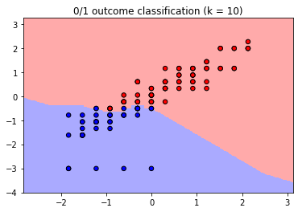

```python
knn = KNeighborsClassifier(n_neighbors=10, p=2, metric='minkowski')
knn.fit(X_train_std, y_train)

#print('The accuracy of the knn classifier is {:.2f} out of 1 on training data'.format(knn.score(X_train_std, y_train)))
#print('The accuracy of the knn classifier is {:.2f} out of 1 on test data'.format(knn.score(X_test_std, y_test)))

plot_decision_regions(X_test_std, y_test, knn)
```

在這裡，我選擇了G1和G2當作feature使用。 Decision boundary是由計算附近最近的n_neighbor(in this case = 10)個點，並標示為其中出現>=5次的label，以此切分出兩塊區域

```python
mat = pd.read_csv("student-mat.csv", sep = ';')
```

```python
mat = pd.get_dummies(mat)
mat = pd.DataFrame(mat)

# Separating out the features
x = mat.drop('G3', axis = 1)

# Separating out the target
y = mat['G3']

# Standardizing the features
x = StandardScaler().fit_transform(x)
```

```python
binary_y = []

# set binary y and 5-level y
for num in y:
    if(num >= 10):
        binary_y.append('pass')
    else:
        binary_y.append('fail')

binary_y = pd.DataFrame(binary_y)
```

```python
pca = PCA(n_components=2)
principalComponents = pca.fit_transform(x)
principalDf = pd.DataFrame(data = principalComponents
             , columns = ['principal component 1', 'principal component 2'])
```

```python
finalDf = pd.concat([principalDf, binary_y], axis = 1)
```

```python
finalDf.columns = ['principal component 1', 'principal component 2', 'G3']
```

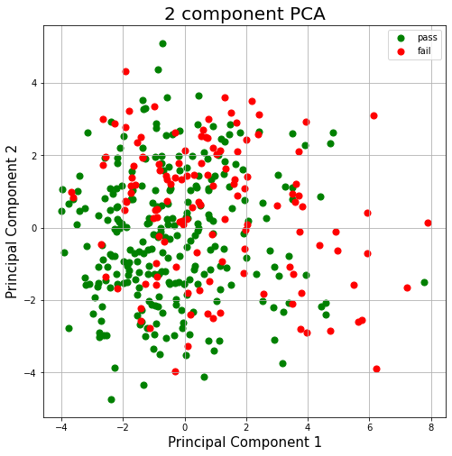

```python
fig = plt.figure(figsize = (8,8))
ax = fig.add_subplot(1,1,1)
ax.set_xlabel('Principal Component 1', fontsize = 15)
ax.set_ylabel('Principal Component 2', fontsize = 15)
ax.set_title('2 component PCA', fontsize = 20)
targets = ['pass', 'fail']
colors = ['g', 'r']
for target, color in zip(targets,colors):
    indicesToKeep = finalDf['G3'] == target
    ax.scatter(finalDf.loc[indicesToKeep, 'principal component 1']
               , finalDf.loc[indicesToKeep, 'principal component 2']
               , c = color
               , s = 50)
ax.legend(targets)
ax.grid()
```